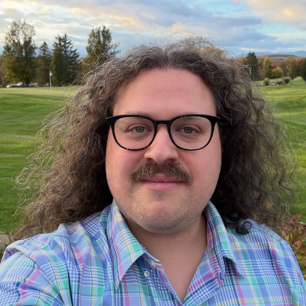

# About Me

👋 Hello! I am a Data Staff Scientist at the [Fred Hutch Data Science Lab](https://hutchdatascience.org/). My work is focused on understanding [data science as a practice](https://courses.csail.mit.edu/18.337/2015/docs/50YearsDataScience.pdf), building a better [developer experience](https://future.a16z.com/the-case-for-developer-experience/) for data scientists, and creating better outcomes in [digital education](https://youtu.be/GG5Vl7N5vCo). I approach these challenges with computational, statistical, ethnographic, and design-driven methods.

Previously I earned my PhD in Human-Computer Interaction at the University of California San Diego where I was advised by [Philip Guo](https://pg.ucsd.edu/). During my PhD I interned at the [Research in Software Engineering Group](https://www.microsoft.com/en-us/research/group/research-software-engineering-rise/) and the [Computational Social Science Group](https://www.microsoft.com/en-us/research/theme/computational-social-science/) at Microsoft Research. Before I started graduate school I was the Chief Technology Officer at the [Johns Hopkins Data Science Lab](https://jhudatascience.org/). I am also a frequent consultant for data analysis and software development projects, in addition to being a maintainer of several open source software projects.

#### Contact

Email: sean at seankross dot com

## Publications

### Conference Papers

Harold Triedman, Jayshree Sarathy, Priyanka Nanayakkara, Rachel Cummings, Gabriel Kaptchuk, **Sean Kross**, Elissa M. Redmiles. *“Having Confidence in My Confidence Intervals”: How Data Users Engage with Privacy-Protected Wikipedia Data.* In Proceedings of CHI 2026: ACM Conference on Human Factors in Computing Systems. [[arXiv]](https://arxiv.org/abs/2512.06534) [[ACM DL]](https://dl.acm.org/doi/10.1145/3772318.3791573)

Sam Lau*, **Sean Kross***, Eugene Wu, Philip J. Guo (*equal contribution). *Teaching Data Science by Visualizing Data Table Transformations: Pandas Tutor for Python, Tidy Data Tutor for R, and SQL Tutor.* In Proceedings of DataEd 2023: The 2nd ACM International Workshop on Data Systems Education. [[Download]](https://seankross.com/dataed-2023/) [[ACM DL]](https://dl.acm.org/doi/10.1145/3596673.3596972)

**Sean Kross**, Philip J. Guo. *Five Pedagogical Principles of a User-Centered Design Course that Prepares Computing Undergraduates for Industry Jobs*. In Proceedings of SIGCSE 2022: The 53rd ACM Technical Symposium on Computer Science Education. [[Download]](https://seankross.com/sigcse-2022/) [[ACM DL]](https://doi.org/10.1145/3478431.3499341)

**Sean Kross**, Philip J. Guo. *Orienting, Framing, Bridging, Magic, and Counseling: How Data Scientists Navigate the Outer Loop of Client Collaborations in Industry and Academia*. In Proceedings of CSCW 2021: ACM Conference on Computer Supported Cooperative Work. [[Download]](https://seankross.com/cscw-2021-sk-pg/) [[ACM DL]](https://doi.org/10.1145/3476052)

**Sean Kross**, Eszter Hargittai, Elissa M. Redmiles. *Characterizing the Online Learning Landscape: What and How People Learn Online*. In Proceedings of CSCW 2021: ACM Conference on Computer Supported Cooperative Work. [[Download]](https://seankross.com/cscw-2021/) [[ACM DL]](https://doi.org/10.1145/3449220)

Xiaoying Pu, **Sean Kross**, Jake Hofman, Daniel Goldstein. *Datamations: Animated Explanations of Data Analysis Pipelines*. In Proceedings of CHI 2021: ACM Conference on Human Factors in Computing Systems. [[Download]](https://seankross.com/chi-2021/) [[ACM DL]](https://doi.org/10.1145/3411764.3445063)

🏆 Elissa M. Redmiles, Noel Warford, Amritha Jayanti, Aravind Koneru, **Sean Kross**, Miraida Morales, Rock Stevens, Michelle L. Mazurek. *A Comprehensive Quality Evaluation of Security and Privacy Advice on the Web*. In Proceedings of the 2020 USENIX Security Symposium. (Distinguished Paper Award) [[USENIX]](https://www.usenix.org/conference/usenixsecurity20/presentation/redmiles)

Elissa M. Redmiles, Lisa Maszkiewicz, Emily Hwang, Dhruv Kuchhal, Everest Liu, Miraida Morales, Denis Peskov, Sudha Rao, Rock Stevens, Kristina Gligorić, **Sean Kross**, Michelle L. Mazurek, Hal Daumé III. *Comparing and Developing Tools to Measure the Readability of Domain-Specific Texts*. In Proceedings of EMNLP 2019: ACL SIGDAT Conference on Empirical Methods in Natural Language Processing. [[Download]](https://seankross.com/emr/emnlp-2019-redmiles.pdf) [[ACL Anthology]](http://dx.doi.org/10.18653/v1/D19-1489)

**Sean Kross**, Philip J. Guo. *End-User Programmers Repurposing End-User Programming Tools to Foster Diversity in Adult End-User Programming Education*. In Proceedings of VL/HCC 2019: IEEE Symposium on Visual Languages and Human-Centric Computing. [[Download]](https://seankross.com/vlhcc-2019/) [[IEEE DL]](https://doi.org/10.1109/VLHCC.2019.8818824)

🏅 **Sean Kross**, Philip J. Guo. *Practitioners Teaching Data Science in Industry and Academia: Expectations, Workflows, and Challenges*. In Proceedings of CHI 2019: The ACM Conference on Human Factors in Computing Systems. (Honorable Mention Paper Award) [[Download]](https://seankross.com/chi-2019/) [[ACM DL]](https://doi.org/10.1145/3290605.3300493)

Elissa M. Redmiles, **Sean Kross**, Michelle L. Mazurek. *How Well Do My Results Generalize? Comparing Security and Privacy Survey Results from MTurk, Web, and Telephone Samples*. In IEEE S&P 2019: The IEEE Symposium on Security and Privacy. [[Download]](https://seankross.com/emr/sp-2019-redmiles-kross-mazurek.pdf) [[IEEE DL]](https://doi.org/10.1109/SP.2019.00014)

Elissa M. Redmiles, Ziyun Zhu, **Sean Kross**, Dhruv Kuchhal, Tudor Dumitras, Michelle L. Mazurek. *Asking for a Friend: Evaluating Response Biases in Security User Studies*. In Proceedings of CCS 2018: The 25th ACM Conference on Computer and Communications Security. [[Download]](https://seankross.com/emr/ccs-2018-redmiles.pdf) [[ACM DL]](https://doi.org/10.1145/3243734.3243740)

**Sean Kross**, Philip J. Guo. *Students, Systems, and Interactions: Synthesizing the First Four Years of Learning@Scale and Charting the Future*. In Proceedings of LAS 2018: The Fifth Annual ACM Conference on Learning at Scale. [[Download]](https://seankross.com/las-2018/) [[ACM DL]](https://doi.org/10.1145/3231644.3231662)

Elissa M. Redmiles, **Sean Kross**, Michelle L. Mazurek. *Where is the Digital Divide? Examining the Impact of Socioeconomics on Security and Privacy Outcomes*. In Proceedings of CHI 2017: The ACM Conference on Human Factors in Computing Systems. [[Download]](https://seankross.com/emr/chi-2017-redmiles-kross-mazurek.pdf) [[ACM DL]](https://doi.org/10.1145/3025453.3025673)

Elissa M. Redmiles, **Sean Kross**, Michelle L. Mazurek. *How I Learned to be Secure: a Census-Representative Survey of Security Advice Sources and Behavior*. In Proceedings of CCS 2016: The 23rd ACM Conference on Computer and Communications Security. [[Download]](https://seankross.com/emr/ccs-2016-redmiles-kross-mazurek.pdf) [[ACM DL]](https://doi.org/10.1145/2976749.2978307)

Elissa M. Redmiles, Mary Allison Abad, Isabella Coronado, **Sean Kross**, Amelia Malone. *A Classroom Tested Accessible Multimedia Resource for Engaging Underrepresented Students in Computing*. In Proceedings of SIGCSE 2015: The 46th ACM Technical Symposium on Computer Science Education. [[ACM DL]](http://dl.acm.org/citation.cfm?id=2691870)

### Journal Papers

Julia Stewart Lowndes, Anna M. Holder, Emily H. Markowitz, Corey Clatterbuck, Amanda L. Bradford, Kathryn Doering, Molly H. Stevens, Stefanie Butland, Devan Burke, **Sean Kross**, Jeffrey W. Hollister, Christine Stawitz, Margaret C. Siple, Adyan Rios, Jessica Nicole Welch, Bai Li, Farnaz Nojavan, Alexandra Davis, Erin Steiner, Josh M. London, Ileana Fenwick, Alexis Hunzinger, Juliette Verstaen, Elizabeth Holmes, Makhan Virdi, Andrew P. Barrett, Erin Robinson *Shifting Institutional Culture to Develop Climate Solutions with Open Science*. In Ecology and Evolution, June 2024. [[E&E]](https://onlinelibrary.wiley.com/doi/10.1002/ece3.11341)

Emily J. Winokur, Cherry Song, Estelita S. Leija, Joanne Chen, **Sean Kross**, Danielle Shamam, Marcelo Aguilar-Rivera, Laleh K. Quinn, Federico Rossano, Andrea A. Chiba. *Reciprocity in Dyads and Triads: Female Rats Alter Their Prosocial Behavior According to the Social Context*. In Animal Behavior and Cognition, August 2023. [[Download]](https://seankross.com/abc-2023/) [[AB&C]](https://www.animalbehaviorandcognition.org/article.php?id=1351)

**Sean Kross**, Jeffery T. Leek, John Muschelli. *Ari: The Automated R Instructor*. In The R Journal, June 2020. [[TRJ]](https://doi.org/10.32614/RJ-2020-023)

Lucy D’Agostino McGowan, **Sean Kross**, Jeffery T. Leek. *Tools for Analyzing R Code the Tidy Way*. In The R Journal, June 2020. [[TRJ]](https://doi.org/10.32614/RJ-2020-011)

**Sean Kross**, Roger D. Peng, Brian S. Caffo, Ira Gooding, Jeffery T. Leek. *The Democratization of Data Science Education*. In The American Statistician, October 2019. [[Download]](https://seankross.com/tas-2019/) [[PeerJ Preprints]](https://doi.org/10.7287/peerj.preprints.3195v1) [[TAS]](https://doi.org/10.1080/00031305.2019.1668849)